# Chapter 2: Linear regression practice

In this exercise, we are using linear regression to evaluate how different learning approaches affect student’s performance in a statistics course.

We will start off by loading the libraries

```r
library(dplyr)
library(GGally)
library(ggplot2)
```

## Read and describe the data

In the data wrangling section, we created a csv file with the data. Let’s load that.

```r
data <- read.csv("data/learning2014_csv.csv")
```

Pick only the combined columns and the columns with participant info

```r
cols <- c("Age", "Attitude", "Points", "gender", "deep", "surf", "stra")
data <- data[cols]
```

Data overview (dimensions [rows and cols] and structure [variables and their datatypes])

```r
dim(data)
```

```
## [1] 166   7
```

```r
str(data)
```

```
## 'data.frame':    166 obs. of  7 variables:
##  $ Age     : int  53 55 49 53 49 38 50 37 37 42 ...
##  $ Attitude: int  37 31 25 35 37 38 35 29 38 21 ...
##  $ Points  : int  25 12 24 10 22 21 21 31 24 26 ...
##  $ gender  : chr  "F" "M" "F" "M" ...
##  $ deep    : num  3.58 2.92 3.5 3.5 3.67 ...
##  $ surf    : num  2.58 3.17 2.25 2.25 2.83 ...
##  $ stra    : num  3.38 2.75 3.62 3.12 3.62 ...
```

THe dataset is about how students learning approaches affect their exam points in a statistics course. The data has combined variables that describe students learning approaches (deep, surface, strategic) and individual variables with participant information (age, gender, attitude towards statistics, exam points)

Summary of the variables:

```r
summary(data)
```

```
##       Age           Attitude         Points         gender
##  Min.   :17.00   Min.   :14.00   Min.   : 7.00   Length:166
##  1st Qu.:21.00   1st Qu.:26.00   1st Qu.:19.00   Class :character
##  Median :22.00   Median :32.00   Median :23.00   Mode  :character
##  Mean   :25.51   Mean   :31.43   Mean   :22.72
##  3rd Qu.:27.00   3rd Qu.:37.00   3rd Qu.:27.75
##  Max.   :55.00   Max.   :50.00   Max.   :33.00
##       deep            surf            stra
##  Min.   :1.583   Min.   :1.583   Min.   :1.250
##  1st Qu.:3.333   1st Qu.:2.417   1st Qu.:2.625
##  Median :3.667   Median :2.833   Median :3.188
##  Mean   :3.680   Mean   :2.787   Mean   :3.121
##  3rd Qu.:4.083   3rd Qu.:3.167   3rd Qu.:3.625
##  Max.   :4.917   Max.   :4.333   Max.   :5.000
```

Plot variable pairs to visualize correlations

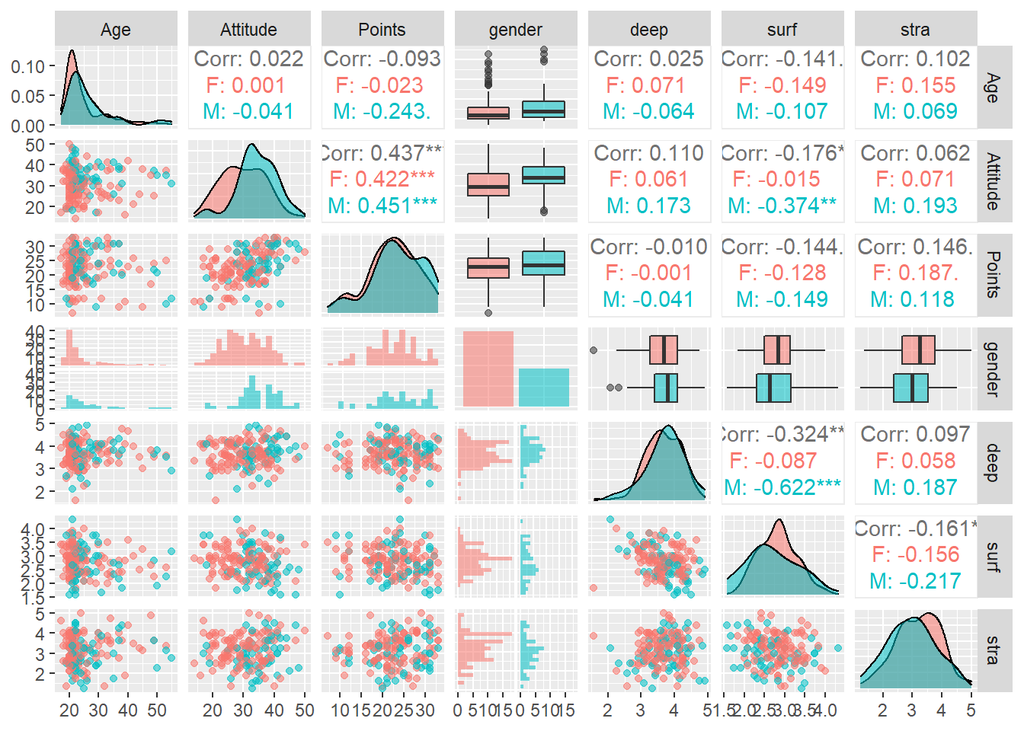

```r
p <- ggpairs(data, mapping = aes(col=gender, alpha=0.3), lower = list(combo = wrap("facethist", bins = 20)))
p
```

## Linear regression models

Let’s fit a model with three variables (strategic approach, surface approach, attitude) and the exam points as the target variable

```r
model <- lm(Points ~ stra + surf + Attitude, data=data)
summary(model)
```

```
##
## Call:
## lm(formula = Points ~ stra + surf + Attitude, data = data)
##
## Residuals:
##      Min       1Q   Median       3Q      Max
## -17.1550  -3.4346   0.5156   3.6401  10.8952
##
## Coefficients:
##             Estimate Std. Error t value Pr(>|t|)
## (Intercept) 11.01711    3.68375   2.991  0.00322 **
## stra         0.85313    0.54159   1.575  0.11716
## surf        -0.58607    0.80138  -0.731  0.46563
## Attitude     0.33952    0.05741   5.913 1.93e-08 ***
## ---
## Signif. codes:  0 '***' 0.001 '**' 0.01 '*' 0.05 '.' 0.1 ' ' 1
##
## Residual standard error: 5.296 on 162 degrees of freedom
## Multiple R-squared:  0.2074, Adjusted R-squared:  0.1927
## F-statistic: 14.13 on 3 and 162 DF,  p-value: 3.156e-08
```

Attitude has a significant effect, the others do not. Let’s fit another model, this time only with Attitude

```r
model2 <- lm(Points ~ Attitude, data=data)
summary(model2)
```

```
##
## Call:
## lm(formula = Points ~ Attitude, data = data)
##
## Residuals:
##      Min       1Q   Median       3Q      Max
## -16.9763  -3.2119   0.4339   4.1534  10.6645
##
## Coefficients:
##             Estimate Std. Error t value Pr(>|t|)
## (Intercept) 11.63715    1.83035   6.358 1.95e-09 ***
## Attitude     0.35255    0.05674   6.214 4.12e-09 ***
## ---
## Signif. codes:  0 '***' 0.001 '**' 0.01 '*' 0.05 '.' 0.1 ' ' 1
##
## Residual standard error: 5.32 on 164 degrees of freedom
## Multiple R-squared:  0.1906, Adjusted R-squared:  0.1856
## F-statistic: 38.61 on 1 and 164 DF,  p-value: 4.119e-09
```

The multiple R-squared measures how well the model fits the data, but also adjusts to the number of fitted variables. The multiple R-squared for the first model was 0.2074. This can be interpreted to mean that the model explains roughly 20.7% of the variance in the data. When we fit the model again with only Attitude as the variable, the R-squared is 0.1906 (~19.1%), meaning that Attitude alone explained a lot of the variance seen in the data.

Diagnosis plots:

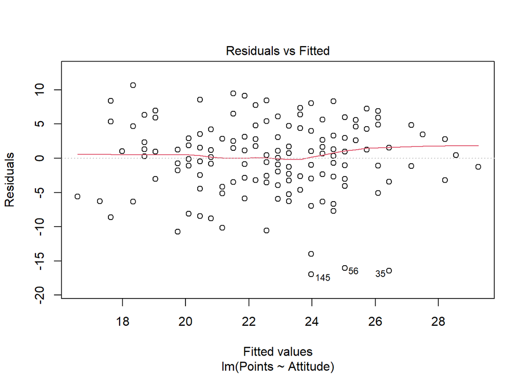

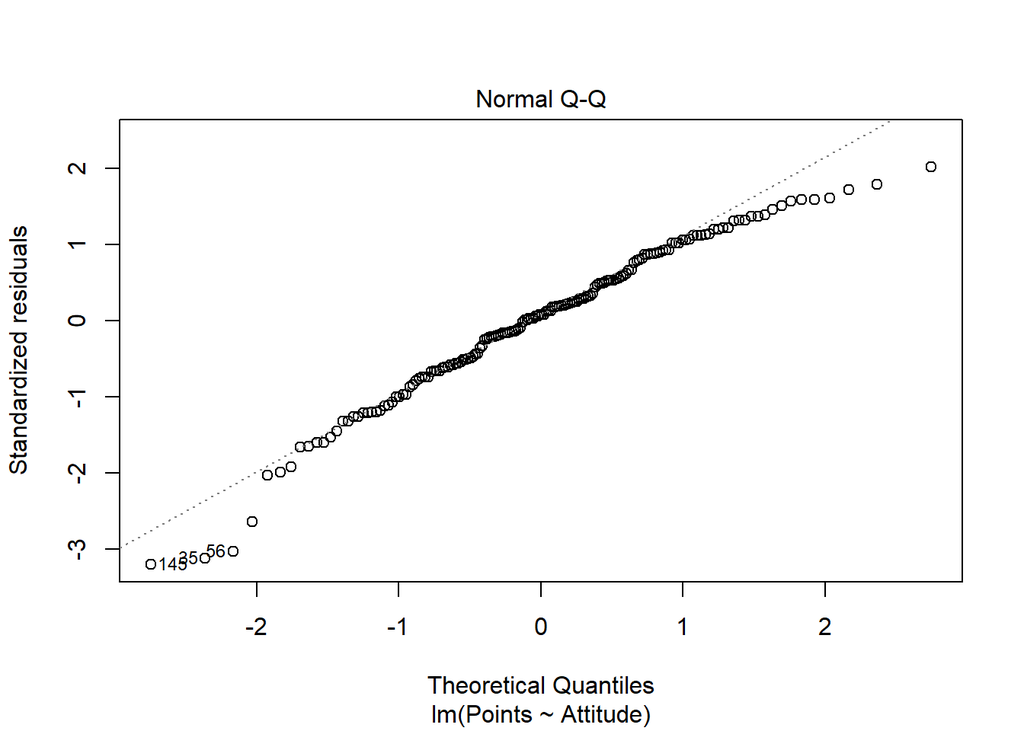

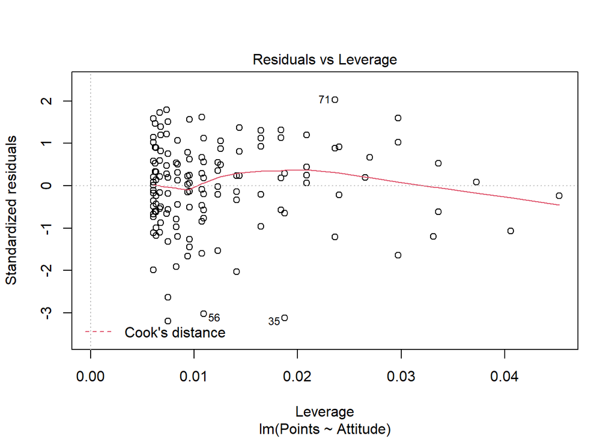

```r
plot(model2, c(1,2,5))
```

In the residuals vs fitted plot, we can see that with larger values the residuals may be getting smaller, although the number of data points is also smaller. Overall there does not seem to be serious heteroscedasticity (residuals should not depend on the fitted values, i.e. they should be randomly distributed).

The QQ-plot shows some deviation from normalcy at the extreme values, however the deviations are smallish and may not violate normality assumptions (errors should be normally distributed).

The residuals vs leverage plot shows that while there are a few points that are kind of outliers, they most likely do not seriously affect the model results.

Finally, let’s plot points vs attitude.

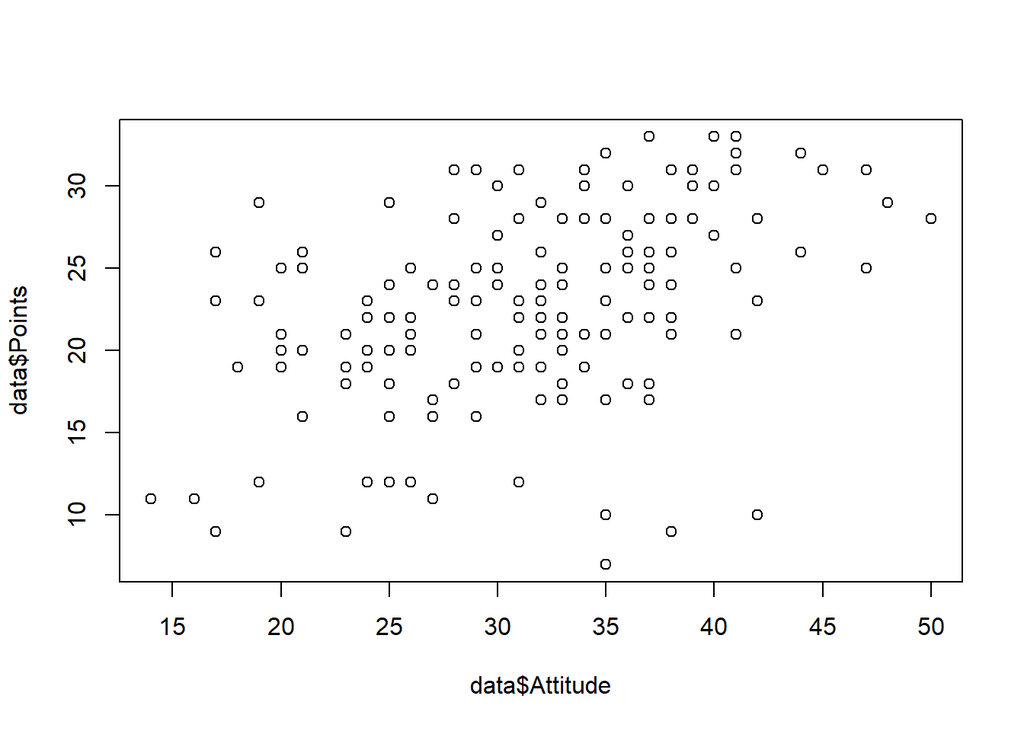

```r
plot(data$Attitude, data$Points)
```